# Lecture #7

R 그래픽: 막대그래프

Junho Ahn

2022-09-08

## 막대그래프를 그려주는 함수

### 막대그래프 그리기

#### 막대그래프의 사용

주로 범주형 자료를 그림으로 표현하기 위해 사용

- 막대의 높이가 해당 범주의 빈도수 또는 비율이 됨
- 각 막개는 일반적으로 분리되도록 그림

#### 사용함수: barplot

매개변수

- height: 기둥의 높이(빈도) 벡터 설정
- horiz: 기둥을 가로로 그릴지 세로로 그릴지 설정, 기본값은 FALSE로 세로 기둥
- beside: 비교 막대그래프
- main, sub: 주제목과 보조제목 설정
- name.arg: 각 기둥 이름
- legend.text: 범례 이름
- col: 각 기둥에 사용할 색깔 설정, 색깔의 이름이나 숫자
- density, angle: 기둥내부를 빗금으로 처리할 때 빗금의 수 및 각도

#### 예제

빈도수, 각 범주의 이름을 각각 freq, category라고 하고 아래와 같이 두 개의 빈도표 그리기

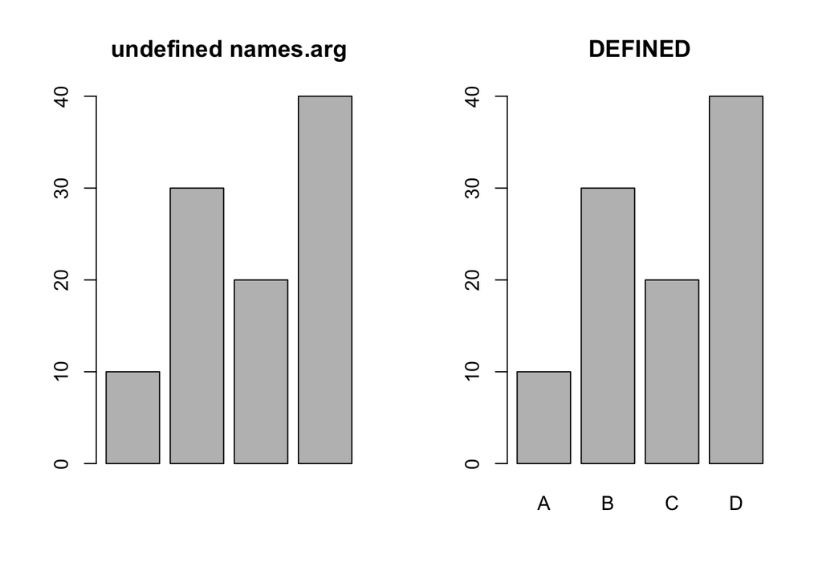

```r
par(mfcol=c(1,2)) # 화면분할을 위해 par()함수 사용, mfcol인자는 그래프를 열 우선 배치
freq <- c(10, 30, 20, 40)
barplot(freq, main="undefined names.arg")
category <- c("A", "B", "C", "D")
barplot(freq, main="DEFINED", names.arg=category)
```

만약 변숫값에 이름이 설정된 경우에는 names.arg를 따로 설정하지 않아도 가로축에 이름이 나타남

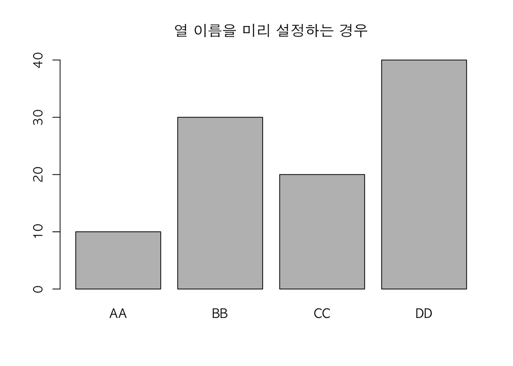

```r
par(family="AppleGothic") # family 설정을 해 주지 않으면 한글 깨짐
freq <- c(10, 30, 20, 40)
names(freq) <- c("AA", "BB", "CC", "DD")
barplot(freq, main="열 이름을 미리 설정하는 경우")
```

### 마이크로 데이터와 색깔

```r
BMI <- read.csv("./Lecture01_BMI.csv")
BMI <- BMI[,-1] #1열에 있는 X(index) 제외
head(BMI)
```

|  | height | weight | year | religion | gender | marriage |
| --- | --- | --- | --- | --- | --- | --- |
| 1 | 167 | 68 | 1974 | No | F | N |
| 2 | 162 | 49 | 1974 | C2 | F | N |
| 3 | 158 | 50 | 1978 | C2 | F | N |
| 4 | 165 | 56 | 1977 | No | F | N |
| 5 | 160 | 52 | 1959 | No | F | N |
| 6 | 162 | 52 | 1972 | No | F | Y |

```r
barplot(BMI$religion) #자료가 문자형이므로 오류 발생

#Error in -0.01 * height : non-numeric argument to binary operator
```

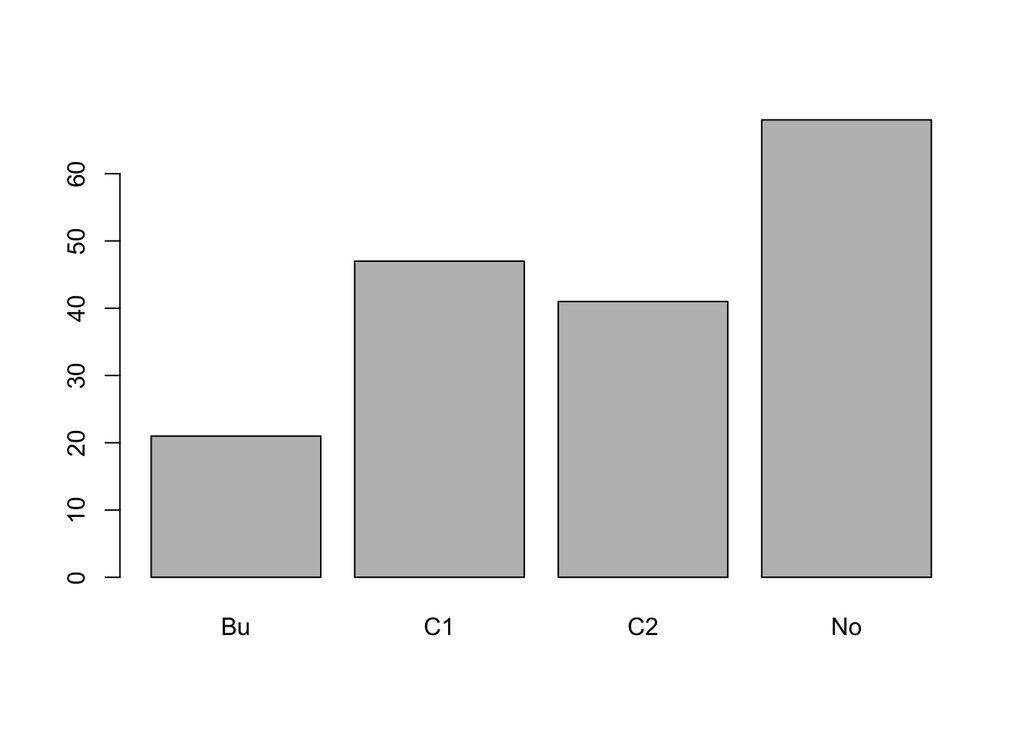

```r
barplot(table(BMI$religion))
```

table()함수를 사용하여 빈도수를 정리하면 막대그래프를 그릴 수 있음  
names.arg를 설정하지 않아도 table()함수의 출력이 각 범주값을 해당 빈도의 이름으로 가지기 때문임.  
가로형태의 그래프를 그리기 위해서는 아래와 같이 horiz=TRUE로 설정

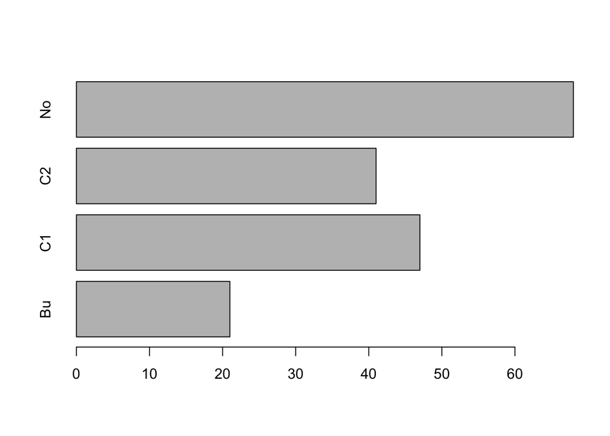

```r
barplot(table(BMI$religion), horiz=TRUE)
```

색깔설정이 필요하면 숫자로 0~8까지 번호를 입력하거나 색이름을 입력

**색번호 (모든 R graphic 동일)**

| 0 | 1 | 2 | 3 | 4 | 5 | 6 | 7 | 8 |
| --- | --- | --- | --- | --- | --- | --- | --- | --- |
| white | black | red | green | blue | cyan | megenta | yellow | gray |

색이름으르 입력할 때는 따옴표(” “)를 사용

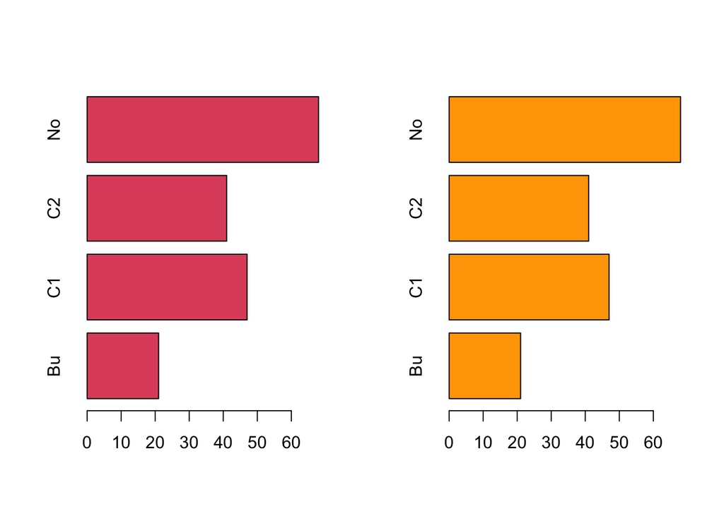

```r
par(mfrow=c(1,2))
barplot(table(BMI$religion), horiz=TRUE, col = 2)
barplot(table(BMI$religion), horiz=TRUE, col = "orange")
```

각 bar에 다른 색깔을 줄 수도 있음

(yaxt 옵션은 y축 눈금표시를 설정하는 옵션인데 “n”은 눈금표시를 않겠다는 의미)

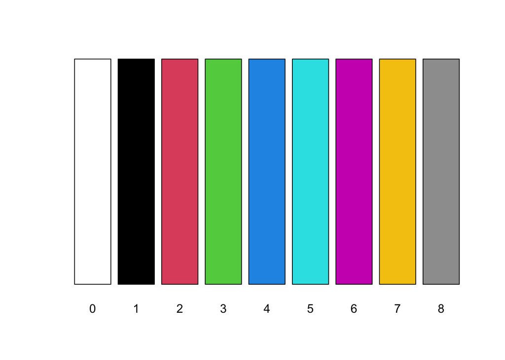

```r
barplot(rep(10,9), col=0:8, names.arg = as.character(seq(0,8)), yaxt="n")
```

### 누적 막대그래프와 비교 막대그래프

두 개 이상의 열을 가진 행렬/데이터 프레임/표가 빈도로 입력될 경우 각 열의 값에 대해서 누적하여 막대그래프를 그림  
첫번째 열은 첫번째 기둥에, 두번째 열은 두번째 기둥 등 순서열을 구분함.  
첫번째 행은 가장 아래, 두번째 행은 두번째 층  
행렬에서 각 원소의 위치와 누적 막대그래프의 각 칸은 행의 순서만 역순인 위치에 있게 됨.

#### 예시1

두 개의 열을 가진 행렬을 사용하여 누적 막대 그래프를 그림

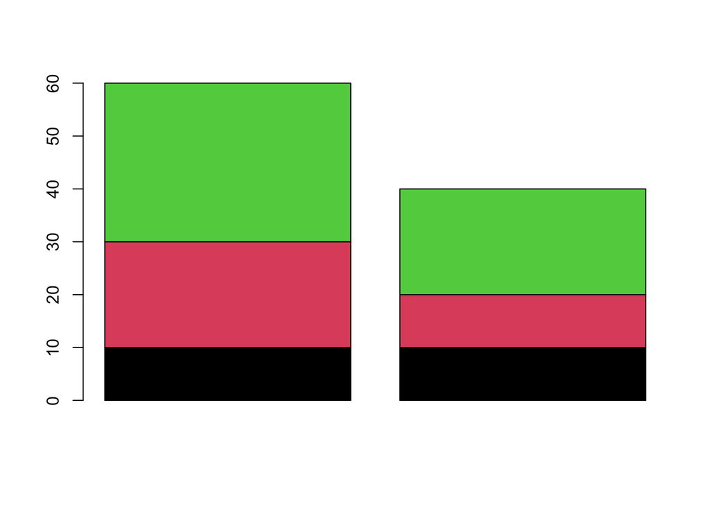

```r
freq <- cbind(c(10, 20, 30), c(10, 10, 20))
barplot(freq, col=1:3)
```

#### 예제2

키,몸무게 자료에서 성별에 따른 종교에 대한 교차표를 `table()`함수로 얻어 이를 막대그래프로 그림

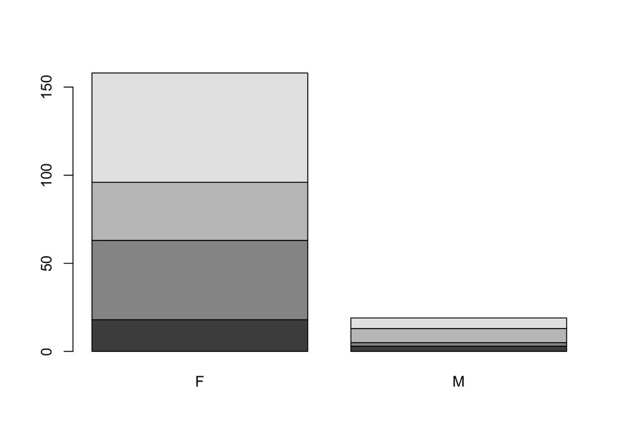

```r
barplot(table(BMI$religion, BMI$gender))
```

```r
table(BMI$religion, BMI$gender)
```

```
##
##       F  M
##   Bu 18  3
##   C1 45  2
##   C2 33  8
##   No 62  6
```

#### 예제3 - 비교막대그래프

각 그룹 별로 기둥을 좌우로 배치하여 그룹간 비교를 직관적으로 할 수 있는 막대그래프로 빈도수를 포함한 행렬을 입력으로 받으며 beside 옵션이 설정되어야 함

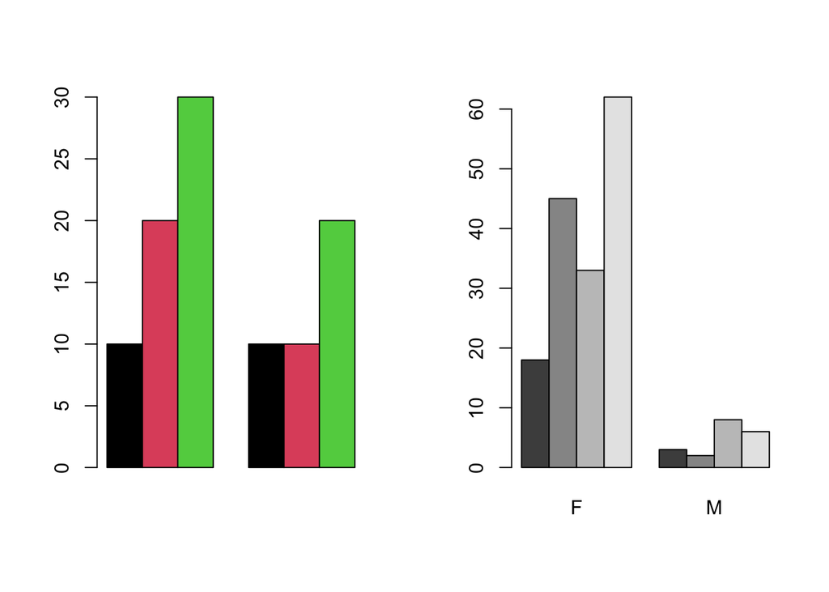

```r
par(mfrow=c(1,2))
barplot(freq, col=1:3, beside = TRUE)
barplot(table(BMI$religion, BMI$gender), beside = TRUE)
```

### 범례추가, 빗금 만들기(density, angle)

#### 범례(legend) 추가

누적 또는 비교 막대 그래프는 가로축엔 이름이 자동 또는 names.arg 옵션으로 넣을 수 있으나 각 그룹 내의 기둥에 대한 구분이 되어 있지 않아 해석하기 불편하므로 이를 해결하기 위해 범례(legend)를 추가할 수 있음

#### 빗금 만들기

색깔이 상자의 내부를 채우는 경우, 천연색이 아닌 흑백이면 구분이 안 가는 경우도 있어 빗금으로 기둥을 채우는 angle 옵션을 설정할 수 있음

빗금의 각도는 angle, 빗금의 밀도는 density 옵션을 사용함. angle = 수평에서 반시계 방향 각도, density = 인치당 빗금수를 입력

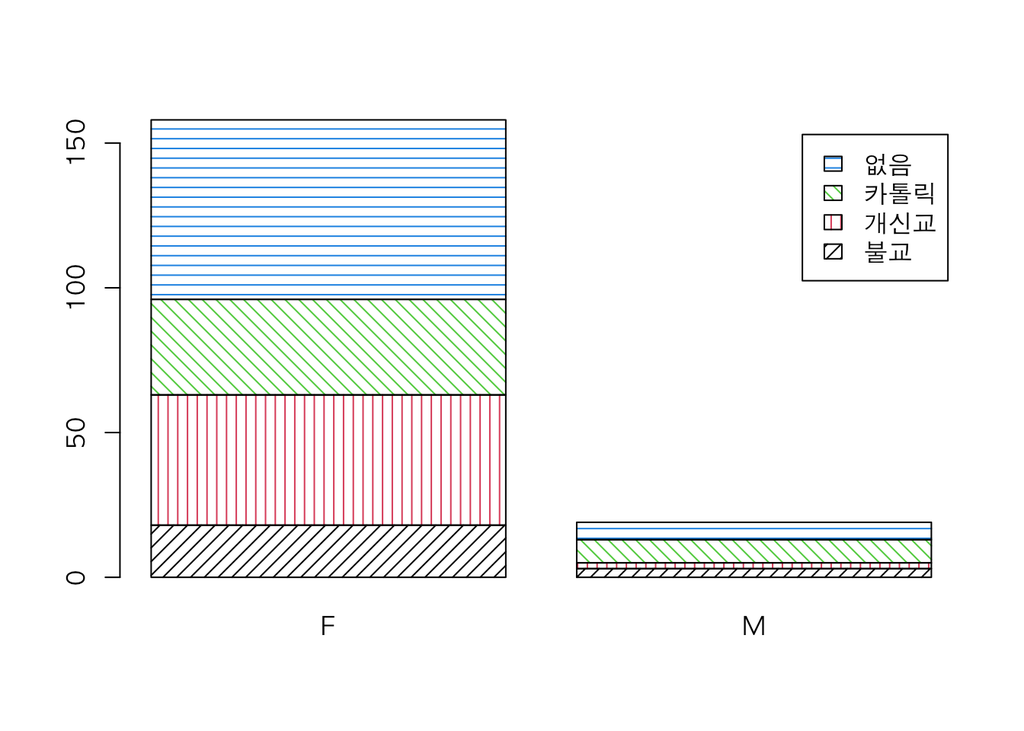

```r
par(family = "AppleGothic")
barplot(table(BMI$religion, BMI$gender), legend.text = c("불교", "개신교", "카톨릭", "없음"),
        col = 1:4, density = 15, angle = c(45, 90, 135, 180))
```

### barplot 함수의 출력

barplot 객체를 변수에 할당하면 각 가둥의 중간에 해당하는 x좌표값을 얻을 수 있음

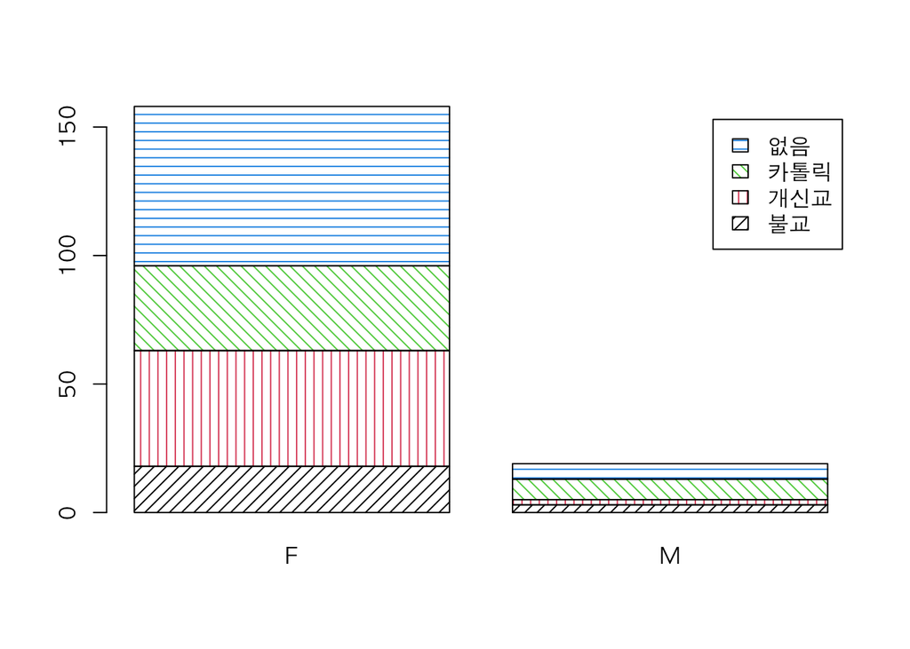

```r
par(family = "AppleGothic")
bpres <- barplot(table(BMI$religion, BMI$gender), legend.text = c("불교", "개신교", "카톨릭", "없음"),
        col = 1:4, density = 15, angle = c(45, 90, 135, 180))
```

```r
bpres
```

```
## [1] 0.7 1.9
```

## 그래픽 장치 설정과 그래픽 옵션 설정

### 그래픽 장치 설정

#### 사용 가능 함수 목록

- win.graph(width, height, …) : 그래픽 윈도우 열기
- png(filename = “Rplot%03d.png”, …) : png 파일로 바로 저장
- jpeg(filename = “Rplot%03d.jpg”, …) : jpg 파일로 바로 저장
- tiff(filename = “Rplot%03d.tif”, …) : tiff 파일로 바로 저장
- dev.off(which=dev.cur()) : 현재의 또는 지정된 그래픽 장치 닫기
- graphics.off() : 모든 그래픽 장치 닫기

#### 함수 사용 예제

```r
jpeg()
barplot(table(BMI$religion, BMI$gender), legend.text = c("불교", "개신교", "카톨릭", "없음"),
        col = 1:4, density = 15, angle = c(45, 90, 135, 180))
dev.off()
```

### 그래픽 옵션 설정

console 창에서 `par()`을 입력하면 현재의 그래픽 설정을 볼 수 있음

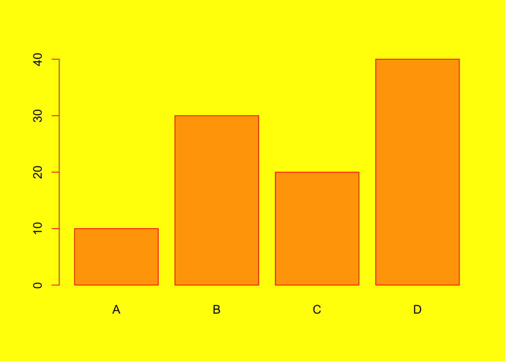

```r
freq <- c(10, 30, 20, 40)
category <- c("A", "B", "C", "D")
par(bg="yellow", fg="red")
barplot(freq, names.arg = category, col = "orange")
```

## 3차원 막대그래프

3차원 막대그래프는 `latticeExtra` package의 `cloud()`함수를 사용

### cloud 함수 사용

매개변수

- x: 행렬이 설정되며 각 원소는 기둥의 높이를 나타낸다. x에 formula: freq ~ x+y형식으로 빈도수, x축, y축에 해당되는 변수를 설정할 수도 있다.
- data: 데이터 프레임 이름
- panel.3d.cloud: 그릴 그림의 형식을 설정하며 3차원 막대그래프는 panel.3d.bars로 설정
- xbase, ybase: 기둥의 바닥 면적 비율
- col.facet, col: 기둥의 면의 색깔 및 선의 색깔 설정
- scales: 그림의 스케일에 대한 속성 설정

### 3차원 막대그래프 그리기

```r
df <- read.table(
text='x freq y
level1 5 high
level1 21 med
level1 4 low
level2 8 high
level2 19 med
level2 3 low
level3 5 high
level3 12 low
level3 50 med', header=TRUE)

df$x <- as.factor(df$x)
df$y <- as.factor(df$y)
```

입력된 자료 df를 사용하여 3차원 막대그래프를 그리기 위해, `library()`를 사용하여 패키지를 load하고 `cloud()`함수 호출하기

```r
library(latticeExtra)
```

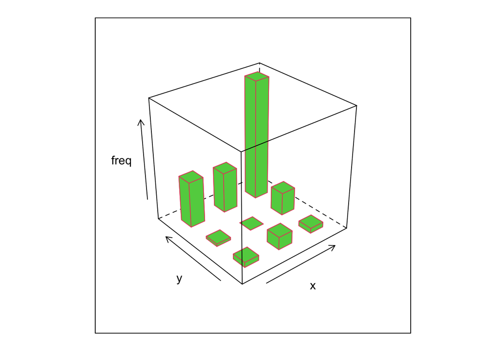

```r
cloud(freq ~ x+y, data = df, panel.3d.cloud=panel.3dbars, xbase=0.4, ybase=0.4, col.facet=3, col=2)
```

기본적인 설정만 사용하여 (x, y)에서의 빈도가 freq인 freq ~ x+y로 기본식을 설정함.  
기둥의 바닥면에 대한 비울을 0.4로, 기둥면과 기둥모서리의 색은 각각 3번색(green), 2번색(red)로 설정함.

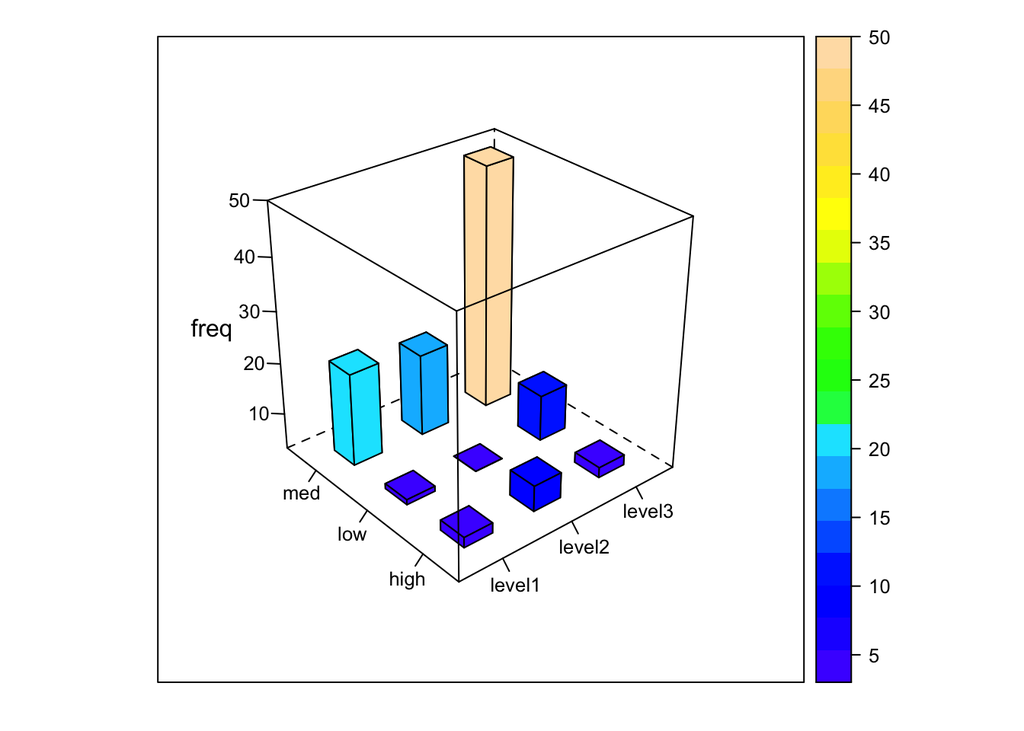

```r
cloud(freq ~ x+y, data = df, panel.3d.cloud=panel.3dbars,
      xbase=0.4, ybase=0.4,
      xlab="", ylab="",
      scales=list(arrows=FALSE, just='right'),
      col.facet=level.colors(df$freq, at= do.breaks(range(df$freq),20),
                             col.regions = topo.colors,
                             colors=TRUE),
      colorkey = list(col=topo.colors, at=do.breaks(range(df$freq),20)))
```

기본 설정은 이전 그래프와 같지만 xlab, ylab에 모두 ““로 설정하여 축의 이름을 삭제  
**scale에 arrow=FALSE, just=’right’로 설정** 하여 화살표 출력 대시 x, y의 값을 출력  
이 문자열은 오른쪽 정렬을 하도로 하였음

col.facet에는 freq의 값을 20개 구간으로 (따라서 21개의 값) 나눈 구간의 끝점에 따라 색을 다르게 설정  
이 때 사용할 색 팔레트는 topo.colors임. 참고로 topo.colors는 **지도에서 사용하는 색** 임.

colorkey는 그림의 오른쪽에서 색에 따른 빈도수 설명을 만들며 이 설명은 topo.colors를 col.facet에 설정된 구간에 적용